# Statistics 651 Normal Sampling Model

Winter 2026

## Objectives

1. Perform analysis with the normal sampling model under various priors

## Resources

- BDA3: Ch 3.1-3.3
- Hoff: Ch 5 (normal)

## Joint vs marginal posterior

**Joint posterior**

$$\pi(\boldsymbol{\theta} \mid \boldsymbol{x}) = \frac{f(\boldsymbol{x} \mid \boldsymbol{\theta}) \, \pi(\boldsymbol{\theta})}{\int_\boldsymbol{\Theta} f(\boldsymbol{x} \mid \boldsymbol{\theta}) \, \Pi(\mbox{d} \boldsymbol{\theta}) }$$

**Marginal posterior**

Splitting up the parameter $\boldsymbol{\theta} = (\boldsymbol{\theta}_1, \boldsymbol{\theta}_2)$, we can write
$$\begin{align}
\pi(\boldsymbol{\theta}_1 \mid \boldsymbol{x}) &= \int_{\boldsymbol{\Theta}_2} \Pi( \boldsymbol{\theta}_1, \, \mbox{d} \boldsymbol{\theta}_2 \mid \boldsymbol{x}) \\
&= \int_{\boldsymbol{\Theta}_2} \pi( \boldsymbol{\theta}_1 \mid \boldsymbol{\theta}_2, \boldsymbol{x}) \, \Pi_2(\mbox{d} \boldsymbol{\theta}_2 \mid \boldsymbol{x}) \, .
\end{align}$$

- Remove nuisance parameters
- Posterior summaries of $\boldsymbol{\theta}_1$ are simpler, and $\mathbb{E}(\boldsymbol{\theta}_1 \mid \boldsymbol{x}) = \mathbb{E}_{\Pi_2}(\mathbb{E}(\boldsymbol{\theta}_1 \mid \boldsymbol{\theta}_2, \boldsymbol{x}))$

# Normal sampling model with $\mu$ and $\sigma^2$ unknown

## Normal model

Prior choices:

- Noninformative
  - Use case: reference analysis
- Fully conjugate
  - Use case: historical info available, computational convenience
- Conditionally conjugate
  - Use case: info available, more flexibility needed
- Alternate variance priors
  - Use case: more realistic, better properties

## Normal model: likelihood

# Normal model: “noninformative” prior

## Normal model: “noninformative” prior

**Noninformative prior**

$\pi(\mu, \sigma^2) \propto \frac{1}{\sigma^2}$

This is equivalent to using $\pi(\mu, \log\sigma) \propto 1$, and is the Jeffreys prior.

Then we can write $\pi(\mu, \sigma^2 \mid \boldsymbol{x}) = \pi(\sigma^2 \mid \boldsymbol{x}) \times \pi(\mu \mid \sigma^2, \boldsymbol{x})$

(See [normal-inverse-gamma distribution](https://en.wikipedia.org/wiki/Normal-inverse-gamma_distribution))

where

## Normal model: “noninformative” prior

**Prior**: $\pi(\mu, \sigma^2) \propto \frac{1}{\sigma^2}$

**Posterior**: $\pi(\mu, \sigma^2 \mid \boldsymbol{x}) = \pi(\sigma^2 \mid \boldsymbol{x}) \times \pi(\mu \mid \sigma^2, \boldsymbol{x})$

with

$\sigma^2 \mid \boldsymbol{x} \sim \mbox{Inv-Gamma}(\frac{n-1}{2}, \frac{(n-1)s^2}{2})$

and

## Normal model: “noninformative” prior

**Prior**: $\pi(\mu, \sigma^2) \propto \frac{1}{\sigma^2}$

**Posterior**: $\pi(\mu, \sigma^2 \mid \boldsymbol{x}) = \pi(\sigma^2 \mid \boldsymbol{x}) \times \pi(\mu \mid \sigma^2, \boldsymbol{x})$

with
$$\begin{align}
\sigma^2 \mid \boldsymbol{x} &\sim \mbox{Inv-Gamma}\left(\frac{n-1}{2}, \, \frac{(n-1)s^2}{2} \right) \, , \\
\mu \mid \sigma^2, \boldsymbol{x} &\sim \mbox{Normal}\left(\bar{x}, \, \frac{\sigma^2}{n} \right) \, .
\end{align}$$

This suggests sequentially sampling $(\mu, \sigma^2)$ from the posterior with the compositional method.

## Sampling from inverse gamma

**Proposition**

**Gamma, Inv-Gamma relation**

If $X \sim \mbox{Gamma}(a, \, \texttt{rate}=b)$,

then $Y = \frac{1}{X} \sim \mbox{Inv-Gamma}(a, \, \texttt{scale} = b)$

- We use scale paramter with inverse-gamma.
- Suggests the following functions:

```r
dinvgamma <- function(x, shape, scale) {
  dgamma(1.0 / x, shape = shape, rate = scale) / x^2
}

rinvgamma <- function(n, shape, scale) {
  1.0 / rgamma(n, shape = shape, rate = scale)
}
```

## Nuisance parameters

**Prior**: $\pi(\mu, \sigma^2) \propto \frac{1}{\sigma^2}$

**Posterior**: $\pi(\mu, \sigma^2 \mid \boldsymbol{x}) = \pi(\sigma^2 \mid \boldsymbol{x}) \times \pi(\mu \mid \sigma^2, \boldsymbol{x})$.

If interest lies only in $\mu$, we can find

$\pi(\mu \mid \boldsymbol{x}) = \int_0^\infty \pi(\sigma^2 \mid \boldsymbol{x}) \times \pi(\mu \mid \sigma^2, \boldsymbol{x}) \, \mbox{d}\sigma^2 \, ,$

which is $\frac{s}{\sqrt{n}} t_{n-1} + \bar{x}$,

where $t_{\text{df}}$ denotes a Student-$t$ distribution with $\text{df}$ degrees of freedom.

## Normal model: “noninformative” prior

**Posterior predictive**

$f(\tilde{x} \mid \boldsymbol{x}) = \int_0^\infty \int_{-\infty}^\infty f(\tilde{x} \mid \mu, \sigma^2) \, \pi(\mu, \sigma^2 \mid \boldsymbol{x}) \, \mbox{d} \mu \, \mbox{d}\sigma^2$

which is
$$s\sqrt{1 + \frac{1}{n}} \times t_{n-1} + \bar{x} \, ,$$

that is, location-scale Student-$t$ with $n-1$ degrees of freedom.

# Normal model: fully conjugate prior

## Normal model: fully conjugate prior

**Fully conjugater prior**

$\pi(\mu, \sigma^2) = \pi(\sigma^2) \times \pi( \mu \mid \sigma^2)$

with
$$\begin{align}
\sigma^2 &\sim \mbox{Inv-Gamma}\left( \frac{n_0}{2}, \, \frac{n_0 s_0^2}{2}\right) \, , \\
\mu \mid \sigma^2 &\sim \mbox{Normal}\left(m_0, \, \frac{\sigma^2}{\kappa_0}\right) \, .
\end{align}$$

## Normal-inverse-gamma distribution

$n_0 = 5$, $s_0^2 = 1$, $m_0 = 0$, $\kappa_0 = 3$

[interactive chart not shown]

## Normal model: fully conjugate prior

**Prior** $\pi(\mu, \sigma^2) = \mbox{Inv-Gamma}\left(\sigma^2; \, \frac{n_0}{2}, \, \frac{n_0 s_0^2}{2} \right) \times \mbox{Normal}\left( \mu ; \, m_0, \, \frac{\sigma^2}{\kappa_0}\right)$

## Normal model: fully conjugate prior

**Posterior** $\pi(\mu, \sigma^2 \mid \boldsymbol{x}) = \mbox{Inv-Gamma}\left(\sigma^2; \, \frac{n_1}{2}, \, \frac{n_1 s_1^2}{2} \right) \times \mbox{Normal}\left( \mu ; \, m_1, \, \frac{\sigma^2}{\kappa_1}\right)$

## Normal model: fully conjugate prior

**Posterior** $\pi(\mu, \sigma^2 \mid \boldsymbol{x}) = \mbox{Inv-Gamma}\left(\sigma^2; \, \frac{n_1}{2}, \, \frac{n_1 s_1^2}{2} \right) \times \mbox{Normal}\left( \mu ; \, m_1, \, \frac{\sigma^2}{\kappa_1}\right)$

- As with the noninformative case, $(\mu, \sigma^2)$ can be sampled sequentially with the compositional method.
- The marginal posterior of $\mu$ is $\sqrt{\frac{n_1 \, s_1^2}{n_1 \, \kappa_1}} \times t_{n_1} + m_1$,

that is, location-scale Student-$t$ with $n_1$ degrees of freedom.

## Normal model: fully conjugate prior

**Posterior predictive**

$f(\tilde{x} \mid \boldsymbol{x}) = \int_0^\infty \int_{-\infty}^\infty f(\tilde{x} \mid \mu, \sigma^2) \, \pi(\mu, \sigma^2 \mid \boldsymbol{x}) \, \mbox{d} \mu \, \mbox{d}\sigma^2$

which is
$$\sqrt{\left( \frac{n_1 \, s_1^2 (\kappa_1 + 1)}{n_1 \, \kappa_1} \right)} \times t_{n_1} + m_1 \, ,$$

that is, location-scale Student-$t$ with $n_1$ degrees of freedom.

# Normal model: conditionally conjugate prior

## Normal model: cond. conjugate prior

**Conditionally conjugate prior**

$\pi(\mu, \sigma^2) = \mbox{Normal}(\mu; \, m_0, \, v_0) \times \mbox{Inv-Gamma}\left(\sigma^2; \, \frac{a_0}{2}, \, \frac{b_0}{2} \right)$

Posterior **complete (or full) conditionals**

$\mu \mid \sigma^2, \boldsymbol{x} \sim \mbox{Normal}(m_1, v_1)$ with
$$v_1 = \frac{1}{\frac{1}{v_0} + \frac{n}{\sigma^2}} \quad \text{and} \quad m_1 = v_1 \times \left(\frac{1}{v_0} m_0 + \frac{n}{\sigma^2} \bar{x} \right) \, ,$$

and

$\sigma^2 \mid \mu, \boldsymbol{x} \sim \mbox{Inv-Gamma}\left(\frac{a_1}{2}, \, \frac{b_1}{2} \right)$ with
$$a_1 = a_0 + n \quad \text{and} \quad b_1 = b_0 + \sum_{i=1}^n (x_i - \mu)^2 \, .$$

## Problems with inverse-gamma

See [Gelman (2006)](https://projecteuclid.org/journals/bayesian-analysis/volume-1/issue-3/Prior-distributions-for-variance-parameters-in-hierarchical-models-comment-on/10.1214/06-BA117A.full), [Polson and Scott (2012)](https://projecteuclid.org/journals/bayesian-analysis/volume-7/issue-4/On-the-Half-Cauchy-Prior-for-a-Global-Scale-Parameter/10.1214/12-BA730.full)

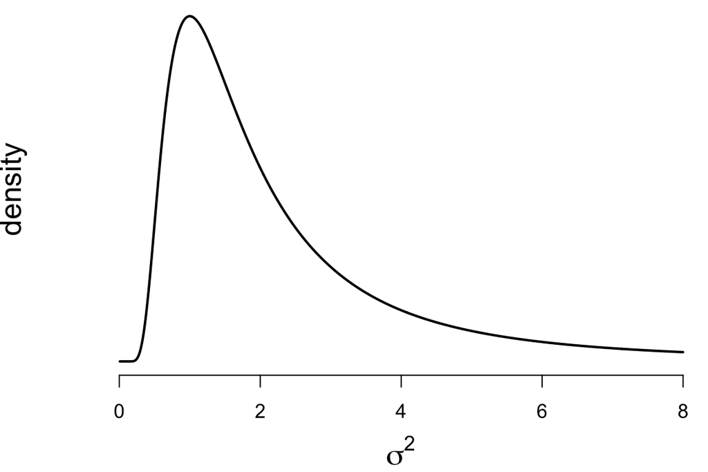

```r
a <- 2
b <- 3

dinvgamma <- function(x, a, b) {
  dgamma(1/x, shape = a, rate = b) / x^2
}

par(mar = c(4,4,0,0) + 0.1)
curve(dinvgamma(x, a = a, b = b), from = 0, to = 8, n = 1000, lwd = 2,
      xlab = expression(sigma^2), ylab = "density", cex.lab = 1.5, axes = FALSE)
axis(side = 1)
```

# Normal model: alternate priors

## Normal model: uniform scale

**Uniform scale prior**

$\pi(\mu, \sigma) = \mbox{Normal}(\mu; \, m_0, \, v_0) \times \mbox{Uniform}(\sigma; \, 0, \, b_\sigma)$

- Uniform on the *standard deviation* rather than variance
- Hard upper boundary on the scale (check for this in the posterior)
- Implies $\pi(\sigma^2) \propto (\sigma^2)^{-1/2} \, 1\{ 0 < \sigma^2 < b_\sigma^2 \}$

## Normal model: Half-Cauchy scale

**Half-Cauchy scale prior**

$\pi(\mu, \sigma) = \mbox{Normal}(\mu; \, m_0, \, v_0) \times \mbox{Cauchy}^+(\sigma; \, s_0)$

where

$\mbox{Cauchy}^+(\sigma; \, s_0) = \frac{2}{\pi s_0} \left( 1 + \frac{\sigma^2}{s_0^2} \right)^{-1} \, 1\{ \sigma > 0 \}$

is a scaled Student-$t$ with 1 degree of freedom, truncated below at 0.

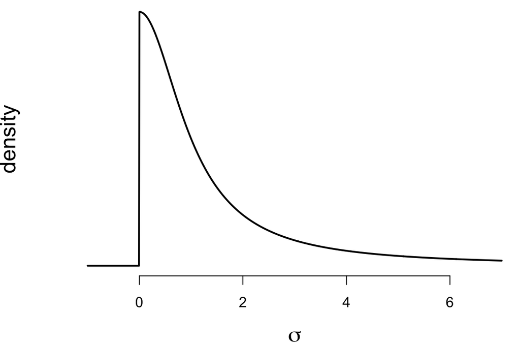

## Normal model: Half-Cauchy scale

The prior $\pi(\sigma) = \mbox{Cauchy}^+(\sigma; \, s_0)$ is equivalent to

$$\begin{align}
\sigma^2 \mid \eta &\sim \mbox{Inv-Gamma}\left(\frac{1}{2}, \, \frac{1}{\eta}\right) \, , \\
\eta &\sim \mbox{Inv-Gamma}\left(\frac{1}{2}, \, \frac{1}{s_0^2}\right) \, .
\end{align}$$

**Complete conditional** distributions:

$$\begin{align}
\sigma^2 \mid \eta, \, \mu, \, \boldsymbol{x} &\sim \mbox{Inv-Gamma}\left(\frac{n+1}{2}, \, \frac{\sum_{i=1}^n (x_i - \mu)^2}{2} + \frac{1}{\eta} \right) \, , \\
\eta \mid \sigma^2, \, \mu, \, \boldsymbol{x} &\sim \mbox{Inv-Gamma}\left(1, \, \frac{1}{\sigma^2} + \frac{1}{s_0^2}\right) \, .
\end{align}$$

# Example

## Zinc data

**Example**

Consider the brass alloy zinc data described in Section 1.2 of BIDA and available at https://blogs.oregonstate.edu/bida/data-sets-and-code/

Assume the model $x_i \overset{\text{iid}}{\sim} \mbox{Normal}(\mu, \sigma^2)$ for $i = 1, \ldots, n$ with $n=12$ and perform an analysis with

- the noninformative prior on $(\mu, \sigma^2)$
- the fully conjugate prior